# ada-reg

## Here are similar Algorithms for Both Regression and Classification:

**Decision Trees:**

- Regression: Decision trees predict continuous values at the leaves by averaging the target values.
- Classification: Decision trees assign categorical labels to data points by traversing through the splits.

**Random Forest:**

- Regression: Random forests average the predictions of multiple decision trees to provide a continuous value.
- Classification: Random forests use a majority vote among trees to assign a class label.

**K-Nearest Neighbors (KNN):**

- Regression: KNN regression predicts a value by averaging the target values of the k-nearest neighbors.
- Classification: KNN classification assigns a label based on the majority class among the k-nearest neighbors.

**AdaBoost:**

- Regression: AdaBoost for regression boosts weak learners to reduce prediction errors.
- Classification: AdaBoost for classification focuses on reducing classification errors by adjusting sample weights after each iteration.

```python
import numpy as np
import pandas as pd

from sklearn.neighbors    import KNeighborsRegressor
from sklearn.ensemble     import AdaBoostRegressor
from sklearn.ensemble     import RandomForestRegressor
from sklearn.tree         import DecisionTreeRegressor
from sklearn.model_selection import GridSearchCV
from sklearn.model_selection import train_test_split
from sklearn.preprocessing   import StandardScaler
from sklearn.metrics import r2_score

import matplotlib.pyplot as plt
import seaborn as sns
```

```python
dataset = pd.read_csv('https://storage.googleapis.com/esmartdata-courses-files/ml-course/insurance.csv')
df = dataset.copy()

for col in df.columns:
    if df[col].dtype == 'object':
        df[col] = df[col].astype('category')

df[df.duplicated()]
df.drop_duplicates(inplace=True)
df = pd.get_dummies(df, drop_first=True, dtype='int')

X = df.copy()
y = X.pop('charges')

scaler = StandardScaler()
X = scaler.fit_transform(X)
X_train, X_test, y_train, y_test = train_test_split(X,y,test_size=0.2)
```

## AdaBoost Regressor

**Description: AdaBoost combines weak learners (typically decision trees) to create a strong model, adjusting weights for instances based on the error of previous models.** **Hyperparameters:**

- n_estimators: Number of boosting stages (trees) to be run.
- learning_rate: Shrinks the contribution of each tree to control overfitting.

```python
# Adaboost regressor
adaboost = AdaBoostRegressor(n_estimators=1000)

params = {
    'n_estimators': [50, 100, 200],  # Number of boosting stages
    'learning_rate': [0.01, 0.1, 1.0]  # Learning rate
}

grid_search = GridSearchCV(adaboost, params, cv=5, scoring='r2')

grid_search.fit(X_train, y_train)

best_params = grid_search.best_params_
best_model = grid_search.best_estimator_

print("Best Parameters:", best_params)
print("Best Model:", best_model)

r2 = best_model.score(X_test, y_test)
print("Test R2:", r2)
y_pred = best_model.predict(X_test)
```

```
Best Parameters: {'learning_rate': 0.01, 'n_estimators': 50}
Best Model: AdaBoostRegressor(learning_rate=0.01)
Test R2: 0.887531294912898
```

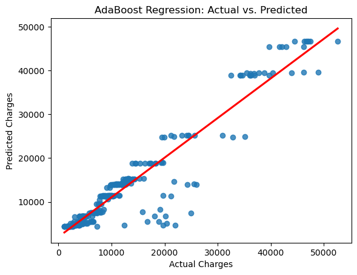

```python
sns.regplot(x=y_test, y=y_pred, line_kws={'color':'red'}, ci=None)
plt.title("AdaBoost Regression: Actual vs. Predicted")
plt.xlabel("Actual Charges")
plt.ylabel("Predicted Charges")
plt.show()
```

## Decision Tree Regressor

**Description: Decision tree regressor splits the data recursively based on feature values to create a tree structure that predicts the target variable by averaging outcomes in the leaf nodes.**

**Hyperparameters:**

- criterion: The function to measure the quality of a split (squared_error, absolute_error, poisson).
- max_depth: Maximum depth of the tree.
- min_samples_split: Minimum number of samples required to split a node.
- min_samples_leaf: Minimum number of samples required in a leaf node.
- max_features: The number of features to consider when looking for the best split.

```python
tree = DecisionTreeRegressor()

params = {
    'criterion': ['squared_error', 'absolute_error', 'poisson'],
    'max_depth': [5, 10],
    'min_samples_split': [2, 5],
    'min_samples_leaf': [1, 2],
    'max_features': ['sqrt', 'log2', None]
}

grid_search = GridSearchCV(tree, params, cv=5, scoring='r2')

grid_search.fit(X_train, y_train)

best_params = grid_search.best_params_
best_model = grid_search.best_estimator_

r2 = best_model.score(X_test, y_test)
print("Tree Regressor R2:", r2)

y_pred = best_model.predict(X_test)
```

```
Tree Regressor R2: 0.8895594543649323
```

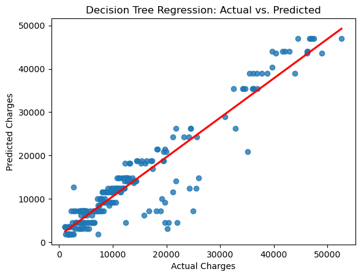

```python
sns.regplot(x=y_test, y=y_pred, line_kws={'color':'red'}, ci=None)
plt.title("Decision Tree Regression: Actual vs. Predicted")
plt.xlabel("Actual Charges")
plt.ylabel("Predicted Charges")
plt.show()
```

## Random Forest Regressor

**Description: Random forest is an ensemble of decision trees, where each tree is trained on a bootstrap sample of the data, and predictions are averaged to improve accuracy and reduce overfitting.**

**Hyperparameters:**

- n_estimators: Number of trees in the forest.
- max_depth: Maximum depth of each tree.
- min_samples_split: Minimum number of samples required to split an internal node.
- min_samples_leaf: Minimum number of samples required in a leaf node.
- max_features: The number of features to consider when looking for the best split.
- bootstrap: Whether to use bootstrap samples when building trees.

```python
randomforest = RandomForestRegressor()

params = {
    'n_estimators': [100, 200],
    'max_depth': [10, 20],
    'min_samples_split': [2, 5, 10],
    'min_samples_leaf': [2, 4],
    'max_features': ['sqrt', 'log2'],
    'bootstrap': [True, False]
}

grid_search = GridSearchCV(randomforest, params, cv=5, scoring='r2', n_jobs=-1, verbose=2)

grid_search.fit(X_train, y_train)

best_params = grid_search.best_params_
best_model = grid_search.best_estimator_

r2 = best_model.score(X_test, y_test)
print("Random Forest R2:", r2)

y_pred = best_model.predict(X_test)
```

```
Fitting 5 folds for each of 144 candidates, totalling 720 fits
Random Forest R2: 0.8910723861429697
```

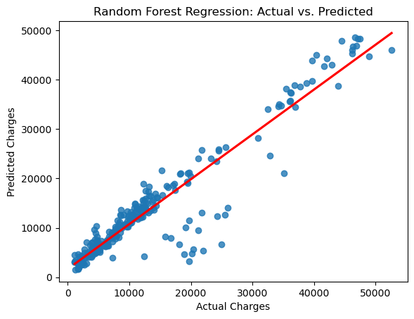

```python
sns.regplot(x=y_test, y=y_pred, line_kws={'color':'red'}, ci=None)
plt.title("Random Forest Regression: Actual vs. Predicted")
plt.xlabel("Actual Charges")
plt.ylabel("Predicted Charges")
plt.show()
```

## K-Nearest Neighbors (KNN) Regressor

**Description: KNN regressor predicts the target value for a data point by averaging the values of its k-nearest neighbors in the feature space.**

**Hyperparameters:**

- n_neighbors: Number of neighbors to consider.
- weights: Weight function to apply to neighbors (uniform or distance).
- algorithm: Algorithm to compute nearest neighbors (auto, ball_tree, kd_tree, brute).
- eaf_size: Leaf size for the tree-based algorithms.
- p: The power parameter for the Minkowski distance metric (1 for Manhattan distance, 2 for Euclidean distance).

```python
kneighbours = KNeighborsRegressor()
params = {
    'n_neighbors': [3, 5, 7, 10],
    'weights': ['uniform', 'distance'],
    'algorithm': ['auto', 'ball_tree', 'kd_tree', 'brute'],
    'leaf_size': [20, 30, 40],
    'p': [1, 2]
}

grid_search = GridSearchCV(kneighbours, params, cv=5, scoring='r2', n_jobs=-1, verbose=2)

grid_search.fit(X_train, y_train)

best_params = grid_search.best_params_
best_model = grid_search.best_estimator_

r2 = best_model.score(X_test, y_test)
print('K-Neighbours R2: {0:.2f}'.format(r2))

y_pred = best_model.predict(X_test)
```

```
Fitting 5 folds for each of 192 candidates, totalling 960 fits
K-Neighbours R2: 0.82
```

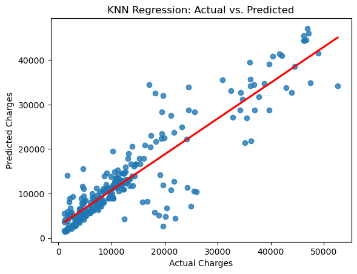

```python
sns.regplot(x=y_test, y=y_pred, line_kws={'color':'red'}, ci=None)
plt.title("KNN Regression: Actual vs. Predicted")
plt.xlabel("Actual Charges")
plt.ylabel("Predicted Charges")
plt.show()
```